# Workflow

Leslie CIETERS[^1]

Nemo DIDIER[^2]

Sara LARCHER[^3]

# 1 **Introduction**

Les maladies simples ou mendéliennes sont **monogéniques**, c’est-à-dire qu’elles sont dues à des anomalies génétiques qui ne concernent qu’un seul gène. Ces anomalies sont situées sur les exons (parties codantes de l’ADN) et souvent très bien étudiées. Elles déclenchent des phénotypes précis, permettant d’identifier facilement le lien entre un phénotype et le gène impliqué. En revanche, les maladies complexes, **multigéniques**, sont liées à plusieurs gènes, chacun d’entre eux n’est ni indispensable, ni suffisant, pour causer à lui seul la maladie. Il s’agit de **gènes de susceptibilité** (Libioulle C., Bours V. Rev Med Liege 2012, 67(5-6),220-225.). Les anomalies peuvent impacter d’autres régions moins bien connues que les exons et plusieurs régions à la fois. Il est donc difficile, à partir des phénotypes, de déterminer les gènes impliqués.

L’**objectif** de ce document est de proposer une démarche complète permettant, pour chaque maladie complexe, d’obtenir une liste de gènes de susceptibilité. Pour cela, nous exploitons les phénotypes des maladies simples et complexes afin d’identifier, pour une maladie complexe, des maladies simples proches, permettant de définir une liste de gènes potentiellement causes de la maladie complexe.

*Cette démarche s’inscrit dans une volonté d’aide à la recherche médicale et ne doit pas être utilisée telle quelle.*

## 1.1 Hypothèses

Nous partons des hypothèses suivantes :

- Il est possible de comprendre les maladies complexes en les rapprochant de maladies simples similaires.
- Nous négligeons l’épistasie (interaction complexe entre l’expression de plusieurs gènes).
- Les phénotypes ne sont pas hiérarchisés. Nous partons du postulat que seul le niveau phénotypique le plus fin est présent dans le jeu de données.

## 1.2 Démarche

Le projet s’articule autour de trois étapes principales :

1. **Calcul des coordonnées des maladies dans un nombre de dimensions finis** : Il s’agit de projeter des maladies simples et complexes dans un espace commun. Nous avons fait le choix d’utiliser uniquement des méthodes basées sur ce principe. Afin de calculer ces coordonnées, nous utilisons donc plusieurs méthodes dont le calcul préalable d’une matrice de distance selon plusieurs métriques. D’autres méthodes permettent l’obtention directe des coordonnées et ne nécessitent pas une étape préalable.
2. **Définition d’un seuil d’assignation des gènes** : On utilise un seuil global ou spécifique à chaque maladie complexe, au travers de plusieurs méthodes, afin de définir notre croyance en une association et donc de conserver une liste d’associations gène-maladie que l’on pense fortement corrélées à la maladie étudiée.
3. **Interprétation des associations gène-maladie** : On définie un score de pertinence de l’association gène-maladie par le biais d’un large modèle de langage (LLM).

À chacune des étapes nous cherchons à comparer plusieurs méthodes pour obtenir la plus adaptée à notre contexte.

## 1.3 Packages requis

Les packages suivants sont utilisés dans ce workflow. Il est également nécessaire d’installer **LLama** pour la partie interprétation des associations qui fait appel à Llama3.

```r
require(ade4)
require(cluster)
require(DataExplorer)
require(factoextra)
require(FactoMineR)
require(knitr)
require(Matrix)
require(ontologyIndex)
require(pheatmap)
require(proxy)
require(reshape)
require(smacof)
require(tidyverse)
require(vegan)
```

# 2 **Préparation des données**

Les données utilisées sont isssues de deux bases de données différentes :

- `OMIM` pour les maladies simples
- `Phecode` pour les maladies complexes

Il s’agit de tableau de Présence/Absence où chaque ligne représente une maladie et chaque colonne un phénotype.

**Structure des données**

|  | Phénotype 1 | Phénotype 2 |
| --- | --- | --- |
| Maladie 1 | 0 | 1 |
| Maladie 2 | 1 | 1 |
| Maladie 3 | 1 | 0 |

Il existe une variabilité intra-maladie pour les phénotypes. Un `1` dans la matrice de présence-absence ne signifie pas que ce phénotype est observé pour l’ensemble des patients atteint de cette maladie. De même un `0` ne signifie pas forcément que le phénotype n’est pas observé pour cette maladie mais qu’il n’est pas observé dans la population étudiée.

La liste des phénotypes peut différer d’une base à une autre. Afin de comparer maladies simples et complexes, nous ne récupérons que les phénotypes communs aux deux bases de données. De plus nous retirons du jeu de données final toutes les maladies ne présentant pas de variabilité dans les phénotypes observés (c’est-à-dire ne présentant que des absences pour l’ensemble des phénotypes étudiés).

## 2.1 Prétraitement

```r
# Importation des données
Phe_OMIM <- read.csv('Profils_Base_OMIM.csv')
Phe_Phecode <- read.csv('Profils_Base_Phecodes.csv')

# Passage des noms de maladies en noms de lignes
rownames(Phe_OMIM) <- Phe_OMIM[,1]
rownames(Phe_Phecode) <- Phe_Phecode[,1]
Phe_OMIM <- Phe_OMIM[,-1]
Phe_Phecode <- Phe_Phecode[,-1]

# Intersection des ensembles de phénotypes des deux bases de données
colonnes_communes <- intersect(colnames(Phe_OMIM), colnames(Phe_Phecode))
Phe_OMIM_communes <- Phe_OMIM[, colonnes_communes, drop = FALSE]
Phe_Phecode_communes <- Phe_Phecode[, colonnes_communes, drop = FALSE]

# Fusion des jeux de données
mc_ms_communes <- rbind(Phe_OMIM_communes, Phe_Phecode_communes)

# Filtre des maladies sans variabilité
mc_ms_communes_filtre_row <- mc_ms_communes %>%
  filter(rowSums(mc_ms_communes)!=0)
mc_ms_communes_filtre_col_row <- mc_ms_communes_filtre_row %>%
  select(where(~sum(.) != 0))
mc_ms_communes_filtre_col_row <- mc_ms_communes_filtre_row[, colSums(mc_ms_communes_filtre_row) != 0]

phenotype_maladie_s_c <- mc_ms_communes_filtre_col_row
phenotype_maladie_s_c <-  as.data.frame(phenotype_maladie_s_c)

# Sauvegarde du jeu de données prétraité
save(phenotype_maladie_s_c, file="phenotype_maladie_s_c.RData")
```

## 2.2 Chargement

Pour plus de facilité d’interprétation et de visualisation, les codes phénotypes initialement utilisés dans le jeu de données sont remplacés par leurs noms exacts.

```r
# Chargement du jeu de données sauvegardé
load('phenotype_maladie_s_c.RData')

# Fichiers HPO pour obtenir le nom des phénotypes
hpo_url <- "https://raw.githubusercontent.com/obophenotype/human-phenotype-ontology/master/hp.obo"
hpo <- get_ontology(hpo_url, extract_tags = 'everything')

name_ph <- hpo$name
formatted_colnames <- gsub("\\.", ":", colnames(phenotype_maladie_s_c))

# Changement des codes phénotypes par leurs noms complets
colnames(phenotype_maladie_s_c) <- name_ph[formatted_colnames]
```

## 2.3 Structure

Avant d’appliquer nos méthodes, nous nous intéressons à la structure des données

```r
# Fonction utilitaire pour calculer le pourcentage de valeurs non-nulles
sparsity_stats <- function(matrix) {
  n_nonzero <- sum(matrix != 0)
  total <- prod(dim(matrix))
  return(list(
    densité = n_nonzero/total * 100,
    nb_nonzero = n_nonzero
  ))
}

## Statistiques descriptives

# Séparation des maladies simples et complexes
maladies_simples <- phenotype_maladie_s_c[1:6102,]
maladies_complexes <- phenotype_maladie_s_c[6103:7064,]

# Calcul des statistiques
stats_total <- sparsity_stats(phenotype_maladie_s_c)
stats_simples <- sparsity_stats(maladies_simples)
stats_complexes <- sparsity_stats(maladies_complexes)

# Affichage des résultats
cat(sprintf("Statistiques de densité de la matrice:\n  - Totale: %.2f%%\n  - Maladies simples: %.2f%%\n  - Maladies complexes: %.2f%%",
            stats_total$densité,
            stats_simples$densité,
            stats_complexes$densité))
```

```
## Statistiques de densité de la matrice:
##   - Totale: 0.55%
##   - Maladies simples: 0.62%
##   - Maladies complexes: 0.10%
```

On observe que la matrice initiale est creuse. Cela est à prendre en compte dans la suite de l’analyse.

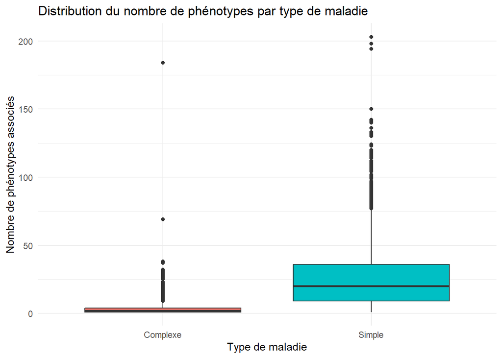

```r
## Distribution des associations par type de maladie
# Calcul du nombre de phénotypes par maladie
phenotypes_par_maladie <- rowSums(phenotype_maladie_s_c != 0)

# Création d'un dataframe pour ggplot
df_dist <- data.frame(
  nb_phenotypes = phenotypes_par_maladie,
  type = c(rep("Simple", 6102), rep("Complexe", 962))
)

# Visualisation avec des boxplots
ggplot(df_dist, aes(x = type, y = nb_phenotypes, fill = type)) +
  geom_boxplot() +
  theme_minimal() +
  labs(title = "Distribution du nombre de phénotypes par type de maladie",
       x = "Type de maladie",
       y = "Nombre de phénotypes associés")+
  theme(legend.position = 'none')
```

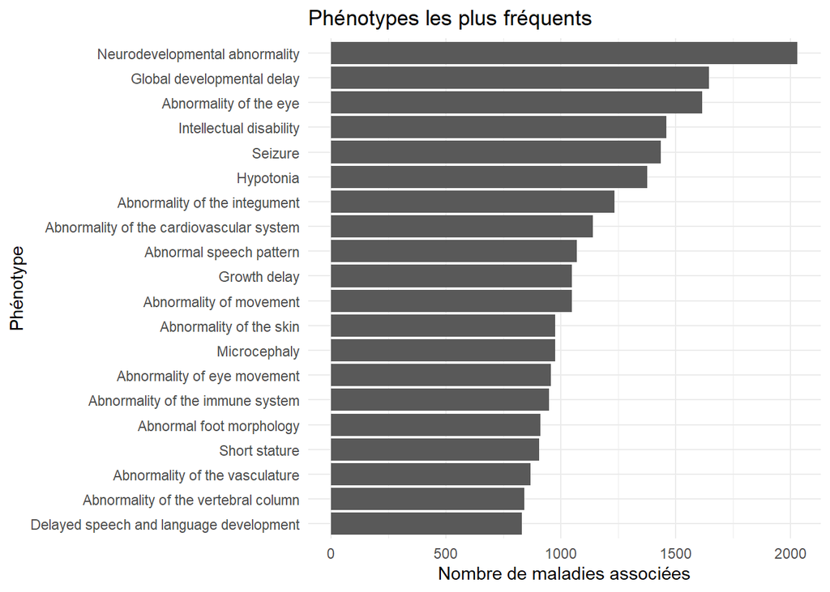

```r
## Analyse des phénotypes les plus fréquents
# Calcul des fréquences des phénotypes
phenotype_freq <- colSums(phenotype_maladie_s_c != 0)
top_n <- 20

# Création d'un dataframe pour les top phénotypes
top_phenotypes <- data.frame(
  phenotype = names(sort(phenotype_freq, decreasing = TRUE)[1:top_n]),
  frequency = sort(phenotype_freq, decreasing = TRUE)[1:top_n]
)

# Visualisation
ggplot(top_phenotypes, aes(x = reorder(phenotype, frequency), y = frequency)) +
  geom_bar(stat = "identity") +
  coord_flip() +
  theme_minimal() +
  labs(title = "Phénotypes les plus fréquents",
       x = "Phénotype",
       y = "Nombre de maladies associées")
```

# 3 **Calcul des matrices de distances**

Ici on cherche à calculer des distances binaires, c’est-à-dire des distances sur une matrice binaire avec **1=Présence** et **0=Absence**.  
On note pour la comparaison de deux maladies :

- $n_{11} = a$ nombre de phénotypes présents dans les deux maladies
- $n_{10} = b$ nombre de phénotypes présents uniquement dans la première maladie
- $n_{01} = c$ nombre de phénotypes présents uniquement dans la deuxième maladie
- $n_{00} = d$ nombre de phénotypes absents dans les deux maladies

## 3.1 Calculs

### Jaccard

Calcule la similarité en fonction de la proportion d’éléments communs.

$$d_{Jaccard}=\sqrt{1-\frac{a}{a+b+c}}$$

```r
index_ASCVD <- which(rownames(phenotype_maladie_s_c) == "ASCVD")
rownames(phenotype_maladie_s_c[6103,])
rownames(phenotype_maladie_s_c[6102,])

dist_or_jaccard <- dist.binary(phenotype_maladie_s_c, method = 1)
dist_or_jaccard <- as.data.frame(as.matrix(dist_or_jaccard))
dist_or_jaccard <- dist_or_jaccard[6103:7064, 1:6102]  # Extraction du sous-ensemble MC-MS
dist_or_jaccard_mx <- as.matrix(dist_or_jaccard)

save(dist_or_jaccard_mx, file="dist_or_jaccard_mx.RData")
```

### Sorensen

Similaire à la distance de Jaccard mais avec un facteur multiplicatif pour augmenter la pondération des présences communes.

$$d_{Sorensen}=\sqrt{1-\frac{2a}{2a+b+c}}$$

```r
dist_or_sorensen <- dist.binary(phenotype_maladie_s_c, method = 5)
dist_or_sorensen <- as.data.frame(as.matrix(dist_or_sorensen))
dist_or_sorensen <- dist_or_sorensen[6103:7064, 1:6102]
dist_or_sorensen_mx <- as.matrix(dist_or_sorensen)

save(dist_or_sorensen_mx, file="dist_or_sorensen_mx.RData")
```

### Sokal et sneath

Variation de la distance de Jaccard qui prend en compte les concordances des absences, c’est-à-dire les différences entre deux maladies (b et c).

$$d_{Sokal-Sneath}=\sqrt{1-\frac{a}{a+2(b+c)}}$$

```r
dist_or_sokal_sneath <- dist.binary(phenotype_maladie_s_c, method = 3)
dist_or_sokal_sneath <- as.data.frame(as.matrix(dist_or_sokal_sneath))
dist_or_sokal_sneath <- dist_or_sokal_sneath[6103:7064, 1:6102]
dist_or_sokal_sneath_mx <- as.matrix(dist_or_sokal_sneath)

save(dist_or_sokal_sneath_mx, file="dist_or_sokal_sneath_mx.RData")
```

### Ochiai

Mesure la similarité en fonction du rapport entre la taille des ensembles et des éléments communs.

$$d_{Ochiai}=\sqrt{1-\frac{a}{\sqrt{(a+b)(a+c)}}}$$

```r
dist_or_ochiai <- dist.binary(phenotype_maladie_s_c, method = 7)
dist_or_ochiai <- as.data.frame(as.matrix(dist_or_ochiai))
dist_or_ochiai <- dist_or_ochiai[6103:7064, 1:6102]
dist_or_ochiai_mx <- as.matrix(dist_or_ochiai)

save(dist_or_ochiai_mx, file="dist_or_ochiai_mx.RData")
```

### Cosine

Similaire à Ochiai pour des données continues. Compare deux ensembles comme des vecteurs dans un espace multidimensionnel.

$$d_{Cosine} = 1 - \frac{a}{\sqrt{(a +
b)(a + c)}}$$

```r
dist_cosine <- dist(phenotype_maladie_s_c, method = "cosine")
dist_cosine <- as.data.frame(as.matrix(dist_cosine))
dist_cosine <- dist_cosine[6103:7064, 1:6102]
dist_or_cosine_mx <- as.matrix(dist_cosine)

save(dist_or_cosine_mx, file="dist_or_cosine_mx.RData")
```

### Rogers et Tanimoto

Mesure la similarité en prenant en compte les présences et les absences.

$$d_{Rogers-Tanimoto}=\sqrt{1-\frac{a+d}{a+2(b+c)+d}}$$

```r
dist_or_rogers_tanimoto  <- dist.binary(phenotype_maladie_s_c, method = 4)
dist_or_rogers_tanimoto <- as.data.frame(as.matrix(dist_or_rogers_tanimoto))
dist_or_rogers_tanimoto <- dist_or_rogers_tanimoto[6103:7064, 1:6102]
dist_or_rogers_tanimoto_mx <- as.matrix(dist_or_rogers_tanimoto)

save(dist_or_rogers_tanimoto_mx, file="dist_or_rogers_tanimoto_mx.RData")
```

### Hamann

Mesure qui prend en compte à la fois la présence et l’absence en équilibrant les deux.

$$d_{Hamann}=\sqrt{1-\frac{a-(b+c)+d}{a+b+c+d}}$$

```r
dist_or_hamann <- dist.binary(phenotype_maladie_s_c, method = 6)
dist_or_hamann <- as.data.frame(as.matrix(dist_or_hamann))
dist_or_hamann <- dist_or_hamann[6103:7064, 1:6102]
dist_or_hamann_mx <- as.matrix(dist_or_hamann)

save(dist_or_hamann_mx, file="dist_or_hamann_mx.RData")
```

### SMC

Le Simple Matching Coefficient (SMC), ou indice de Sokal et Michener, calcule la proportion de concordances parmi tous les éléments.

$$d_{SMC}=\sqrt{1-\frac{a+d}{a+b+c+d}}$$

```r
dist_or_sokal_michener <- dist.binary(phenotype_maladie_s_c, method = 2)
dist_or_sokal_michener <- as.data.frame(as.matrix(dist_or_sokal_michener))
dist_or_sokal_michener <- dist_or_sokal_michener[6103:7064, 1:6102]
dist_or_sokal_michener_mx <- as.matrix(dist_or_sokal_michener)

save(dist_or_sokal_michener_mx, file="dist_or_sokal_michener_mx.RData")
```

## 3.2 Comparaison

Comparaison des méthodes de distance

| Méthode | Pertinence | Avantages | Inconvénients |
| --- | --- | --- | --- |
| Jaccard | Bien adapté pour des données où l’absence est fréquente et où seules les présences sont d’intérêt. | Simple à calculer et interpréter. Bien adapté pour les données creuses. | Ne prend pas en compte les absences simultanées. |
| Sorensen | Utilisée lorsqu’on souhaite plus de poids pour les éléments présents, ce qui est pertinent dans certains jeux de données. | Facile à calculer, adaptée pour les données avec une dominance de présence. | Ne prend pas bien en compte les absences, moins efficace pour des données très creuses. |
| Sokal et Sneath | Pertinente pour des données binaires où les absences sont aussi importantes que les présences. | Bien équilibré entre présence et absence. | Plus complexe à interpréter que le Jaccard. |
| Ochiai | Adaptée aux données binaires où l’on veut une mesure de similarité robuste, même pour les ensembles de taille inégale. | Bien adaptée aux données binaires déséquilibrées, calcul rapide. | Moins efficace avec des ensembles ayant de nombreuses absences simultanées. |
| Cosine | Très adaptée aux données creuses où les ensembles peuvent être représentés comme des vecteurs binaires. | Prend bien en compte la direction des vecteurs, souvent utilisé dans des contextes avec des données creuses. | Peut ne pas être adaptée aux ensembles avec des distributions très inégales des présences et absences. |
| Rogers et Tanimoto | Adaptée lorsque les absences sont importantes et qu’on veut différencier les éléments présents et absents. | Permet une comparaison nuancée, plus détaillée que la distance de Jaccard. | Moins robuste si les absences sont trop fréquentes. |
| Hamann | Utile pour des données où l’absence et la présence sont toutes deux importantes et où l’équilibre est nécessaire. | Robuste et équilibrée entre présence et absence. | Plus difficile à interpréter et peut être moins intuitive dans des jeux de données simples. |
| SMC | Convient pour des ensembles où la présence et l’absence sont toutes deux significatives. | Prend en compte les absences et les présences. | Peut accorder trop de poids aux absences, ce qui n’est pas toujours pertinent. |

L’ensemble de ces distances peuvent être pertinentes selon le contexte. Dans notre cas, nous privilégierons les calculs de distances ne prenant pas en compte les absences communes.

Les calculs de distance étant assez longs, nous avons sauvegardé les matrices dans des objets RData. Le code suivant permet de charger les matrices dans notre environnement

```r
load("dist_or_sokal_sneath_mx.RData")
load("dist_or_hamann_mx.RData")
load("dist_or_rogers_tanimoto_mx.RData")
load("dist_or_sokal_michener_mx.RData")
load("dist_or_cosine_mx.RData")
load("dist_or_jaccard_mx.RData")
load("dist_or_ochiai_mx.RData")
load("dist_or_sorensen_mx.RData")
```

# 4 **Transport Optimal (TO)**

Le transport optimal est une méthode qui permet de déterminer la manière la plus efficace de redistribuer une masse (ou une probabilité) d’un point à un autre, tout en minimisant un coût global associé au déplacement, souvent basé sur une mesure de distance ou un critère spécifique. Dans notre cas, on cherche à déplacer les maladies simples sur les maladies complexes.

## 4.1 Définition de la fonction de TO

```r
sinkhorn_transport <- function(a, b, M, reg, numItermax=1000, stopThr=1e-9) {
  # a, b: distributions marginales
  # M: matrice de coût
  # reg: paramètre de régularisation
  # numItermax: nombre maximum d'itérations
  # stopThr: seuil de convergence
  n <- length(a)
  m <- length(b)
  # Initialisation
  u <- rep(1/n, n)
  v <- rep(1/m, m)
  K <- exp(-M/reg)

  # Boucle de Sinkhorn
  for(i in 1:numItermax) {
    u_prev <- u
    # Mise à jour de u et v
    u <- a/(K %*% v)
    v <- b/(t(K) %*% u)
    # Vérification de la convergence
    err <- sum(abs(u - u_prev))
    if(err < stopThr) break
  }
  # Calcul de la matrice de transport
  P <- diag(as.vector(u)) %*% K %*% diag(as.vector(v))
  return(P)
}
```

## 4.2 Utilisation

```r
# Utilisation sur la matrice Jaccard
# Normalisation des vecteurs marginaux
a <- rep(1/nrow(dist_or_jaccard_mx), nrow(dist_or_jaccard_mx))
b <- rep(1/ncol(dist_or_jaccard_mx), ncol(dist_or_jaccard_mx))

# Application de l'algorithme de Sinkhorn
transport_matrix <- sinkhorn_transport(
  a = a,
  b = b,
  M = dist_or_jaccard_mx,
  reg = 0.1  # paramètre de régularisation à ajuster
)

# Calcul de la matrice de distance avec transport optimal
ot_matrix <- dist_or_jaccard_mx * transport_matrix
ot_matrix <- as.matrix(ot_matrix)
ot_matrix <- as.data.frame(ot_matrix)

# ot_matrix_numeric <- ot_matrix %>%
#    mutate(across(everything(), ~ as.numeric(as.character(.))))
dist_ot_jaccard  <- as.data.frame(1 - ot_matrix)
dist_ot_jaccard_mx <- as.matrix(dist_ot_jaccard)
save(dist_ot_jaccard_mx, file="dist_ot_jaccard_mx.RData")
```

Le calcul de la matrice de Transport optimal étant assez long, la matrice a été sauvegardée dans l’objet RData `dist_ot_jaccard_mx.RData`.

```r
load("dist_ot_jaccard_mx.RData")
```